# 03. Tutorial on how to study the variation of AUC-ROC score at varying sequencing depth

Edoardo Giuili

2025-09-24

## Introduction

In this tutorial we want to show how to analyse the robustness of the tools when increasing/decreasing the sequencing depth of the mixtures. Particularly, we will use the AUC-ROC score and look whether this score drastically changes.

### Setting up the environment

First, set up the main directory chaning the paths below

```r
knitr::opts_knit$set(root.dir = '~/OneDrive-UGent/Projects/002_Benchmarking/BenchmarkingAnalysis/')
# Define the directory containing the CSV files
dir_path <- "~/OneDrive-UGent/Projects/002_Benchmarking/BenchmarkingAnalysis/"
```

Import the necessary libraries for the analysis

```r
library(ggpubr)
library(dplyr)
library(tidyverse)
library(pROC)
```

Now, we will import all the results generated on the in silico mixtures. Note that here we expect that you have git cloned the repository and thus have the expected folder structure where in the folder resources/ there are the results files.

```r
df_raw <- read.csv(paste0(dir_path,"resources/final_benchmarking_dataset.csv"))
bench.res <- subset(df_raw, df_raw$mixture_type == "in_silico") %>%
  filter(!is.na(predicted_tf))
```

Import the useful functions and the metrics

```r
source("R/compute_auc.R")

# RMSE
rmse <- function(actual, predicted) {
  round(sqrt(mean((actual - predicted)^2)),4)
}
# Normalized RMSE (NRMSE)
nrmse <- function(actual, predicted) {
    round(sqrt(mean((actual - predicted))^2)/mean(actual+10e-8),4)
}
# Spearman's rank correlation coefficient (SCC)
scc <- function(actual, predicted) {
  cor(actual, predicted, method = "spearman", use = "pairwise.complete.obs")
}
roc.obj <- function(true_labels, predicted_scores) {
  true_labels[true_labels>0] <- 1
  roc_obj <- roc(true_labels, predicted_scores, quiet = TRUE)
  return(roc_obj)
}
```

## WGBS

We will start analysing the WGBS in silico mixtures, to then proceed to the RRBS datasets. First, we will subset the results to only keep the WGBS samples.

```r
bench_wgbs <- subset(bench.res,bench.res$seq_method=="wgbs")
```

We can now compute the AUC-ROC score. Differently from the 01_ tutorial, here we will use the raw AUC-ROC score without min-max scaling it across deconvolution tools. This is necessary since we want to check, within each deconvolution tool, whether the performance changes varying the sequencing depth.

```r
# Create a new dataset dataframe where to store AUC-ROC results
aucroc_data <- data.frame()
# Select the samples with tumoral fractions > 0%
unique_fractions <- unique(bench_wgbs$expected_tf)
unique_fractions <- subset(unique_fractions, unique_fractions != 0)

# Loop over the type of tumors
for (type in unique(bench_wgbs$tumor_type)) {

  # Loop over sequencing depths
  filt_tum <- subset(bench_wgbs, bench_wgbs$tumor_type == type)
  for (seqdepth in unique(filt_tum$seq_depth)) {

    # Loop over the DMR tools
    filt_depth <- subset(filt_tum, filt_tum$seq_depth == seqdepth)
    for (dmrtool in unique(filt_depth$dmr_tool)) {

      # Loop over the deconvolution tools
      for (deconv in unique(filt_depth$deconv_tool)) {

        # Loop over the tumoral fractions specified above
        for (fraction in unique_fractions) {
          filt_df <- filt_depth %>%
            filter(expected_tf %in% c(0,fraction) &
                   dmr_tool == dmrtool &
                   deconv_tool == deconv)

          # Compute the AUC-ROC score per combination and concatanate it to the final dataframe
          auc_single_combination <- compute_auc(filt_df, fraction, deconv)
          aucroc_data <- rbind(aucroc_data, auc_single_combination)
        }
      }
    }
  }
}


auc_wgbs <- aucroc_data %>%
    group_by(deconv_tool, dmr_tool, tumor_type, seq_depth, expected_tf) %>%
    summarize(AUC=mean(auc),.groups = "drop") %>%
    group_by(deconv_tool, dmr_tool, tumor_type, seq_depth) %>%
    summarize(AUC=mean(AUC),.groups = "drop")
```

We can now plot the AUC-ROC score distribution using the boxplots across the different sequencing depths, for each tool and for each different tumor type.

```r
# Create a directory to save the plots (optional)
output_dir <- paste0(dir_path,"plots/03_seqdepth_robustness")
if (!dir.exists(output_dir)) dir.create(output_dir)

# Order the seq depths levels
auc_wgbs$seq_depth <- factor(auc_wgbs$seq_depth, levels = c("62M", "183M", "310M", "620M"))

# Define comparisons
my_comparisons <- list(
  c("62M", "183M"),
  c("62M", "310M"),
  c("62M", "620M")
)

# Loop over the tumor types
for (tum in unique(auc_wgbs$tumor_type)) {

  # Subset the dataframe on the tumor type
  df <- subset(auc_wgbs, auc_wgbs$tumor_type==tum)

  # Plot with adjusted p-values (FDR) and significance only if p.adj < 0.05
  p1 <- ggplot(df, aes(x = seq_depth, y = AUC, fill = seq_depth)) +
    geom_boxplot(outlier.shape = NA) +
    facet_wrap(~ deconv_tool, ncol = 5) +
    stat_compare_means(
      method = "wilcox.test", comparisons = my_comparisons,
      p.adjust.method = "BH", label = "adj.p", hide.ns = F,
      method.args = list(alternative="less"),
      label.y = c(1, 1.05, 1.10), size = 3
    ) +
    labs(
      title = paste0("WGBS (",tum,") dataset"),
      x = "Sequencing Depth",
      y = "AUC"
    ) +
    theme_classic() +
    theme(axis.text.x = element_blank(),
          axis.ticks.x = element_blank(),
          panel.grid.major.y = element_line(color = "grey90"),
          panel.grid.minor.y = element_line(color = "grey90")) +
    scale_fill_manual(values = c("62M"="#FAEBDDFF","183M"="#F69C73FF","310M"="#A11A5BFF","620M"="#03051AFF")) +
    ylim(0.5,1.2)

  # Save the plot as an image
  output_file <- file.path(output_dir, paste0("robustness_AUC_WGBS_",tum,".svg"))
  ggsave(output_file, plot = p1, width = 8, height = 6)
}
```

And here we will generate the same plot as above, just aggregating all the tumors together to have a general overview.

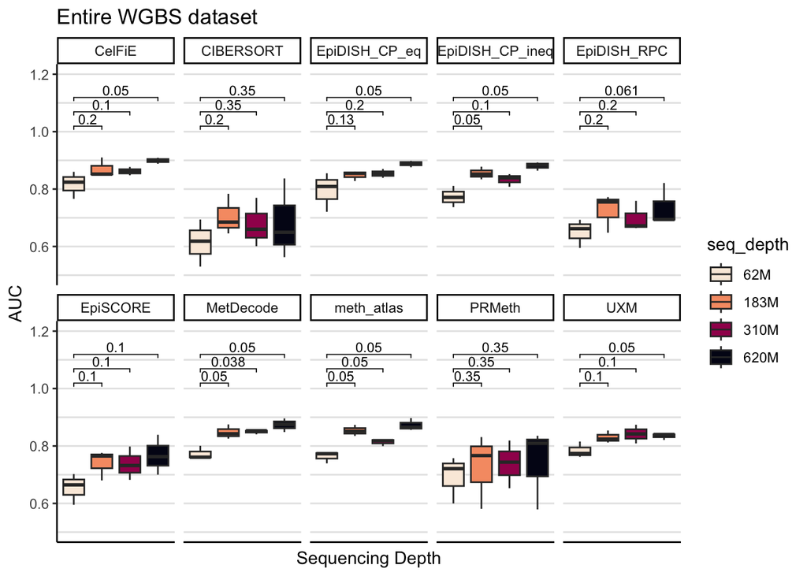

```r
# Order the seq depths levels
auc_wgbs$seq_depth <- factor(auc_wgbs$seq_depth, levels = c("62M", "183M", "310M", "620M"))

# Define comparisons
my_comparisons <- list(
  c("62M", "183M"),
  c("62M", "310M"),
  c("62M", "620M")
)

# Plot with adjusted p-values (FDR) and significance only if p.adj < 0.05
p1 <- ggplot(df, aes(x = seq_depth, y = AUC, fill = seq_depth)) +
    geom_boxplot(outlier.shape = NA) +
    facet_wrap(~ deconv_tool, ncol = 5) +
    stat_compare_means(
      method = "wilcox.test", comparisons = my_comparisons,
      p.adjust.method = "BH", label = "adj.p", hide.ns = F,
      method.args = list(alternative="less"),
      label.y = c(1, 1.05, 1.10), size = 3
    ) +
    labs(
      title = "Entire WGBS dataset",
      x = "Sequencing Depth",
      y = "AUC"
    ) +
    theme_classic() +
    theme(axis.text.x = element_blank(),
          axis.ticks.x = element_blank(),
          panel.grid.major.y = element_line(color = "grey90"),
          panel.grid.minor.y = element_line(color = "grey90")) +
    scale_fill_manual(values = c("62M"="#FAEBDDFF","183M"="#F69C73FF","310M"="#A11A5BFF","620M"="#03051AFF")) +
    ylim(0.5,1.2)
p1
```

```r
# Create a directory to save the plots (optional)
output_dir <- paste0(dir_path,"plots/03_seqdepth_robustness")
if (!dir.exists(output_dir)) dir.create(output_dir)

# Save the plot as an image
output_file <- file.path(output_dir, paste0("robustness_WGBS_aggregated.svg"))
ggsave(output_file, plot = p1, width = 8, height = 6)
```

## RRBS

We can try proceed with the RRBS dataset, in the same way as we did with the WGBS dataset.

```r
bench_rrbs <- subset(bench.res,bench.res$seq_method=="rrbs")
```

```r
# Create a new dataset dataframe where to store AUC-ROC results
aucroc_data <- data.frame()
# Select the samples with tumoral fractions > 0%
unique_fractions <- unique(bench_rrbs$expected_tf)
unique_fractions <- subset(unique_fractions, unique_fractions != 0)

# Loop over the type of tumors
for (type in unique(bench_rrbs$tumor_type)) {

  # Loop over sequencing depths
  filt_tum <- subset(bench_rrbs, bench_rrbs$tumor_type == type)
  for (seqdepth in unique(filt_tum$seq_depth)) {

    # Loop over the DMR tools
    filt_depth <- subset(filt_tum, filt_tum$seq_depth == seqdepth)
    for (dmrtool in unique(filt_depth$dmr_tool)) {

      # Loop over the deconvolution tools
      for (deconv in unique(filt_depth$deconv_tool)) {

        # Loop over the tumoral fractions specified above
        for (fraction in unique_fractions) {
          filt_df <- filt_depth %>%
            filter(expected_tf %in% c(0,fraction) &
                   dmr_tool == dmrtool &
                   deconv_tool == deconv)

          # Compute the AUC-ROC score per combination and concatanate it to the final dataframe
          auc_single_combination <- compute_auc(filt_df, fraction, deconv)
          aucroc_data <- rbind(aucroc_data, auc_single_combination)
        }
      }
    }
  }
}


auc_rrbs <- aucroc_data %>%
    group_by(deconv_tool, dmr_tool, tumor_type, seq_depth, expected_tf) %>%
    summarize(AUC=mean(auc),.groups = "drop") %>%
    group_by(deconv_tool, dmr_tool, tumor_type, seq_depth) %>%
    summarize(AUC=mean(AUC),.groups = "drop")
```

We can now plot the AUC-ROC score distribution using the boxplots across the different sequencing depths, for each tool and for each different tumor type.

```r
# Create a directory to save the plots (optional)
output_dir <- paste0(dir_path,"plots/03_seqdepth_robustness")
if (!dir.exists(output_dir)) dir.create(output_dir)

# Order the seq depths levels
auc_rrbs$seq_depth <- factor(auc_rrbs$seq_depth, levels = c("2M", "5M", "10M", "15M", "20M"))

# Define comparisons
my_comparisons <- list(
  c("2M", "5M"),
  c("2M", "10M"),
  c("2M", "15M"),
  c("2M", "20M")
)

# Loop over the tumor types
for (tum in unique(auc_rrbs$tumor_type)) {

  # Subset the dataframe on the tumor type
  df <- subset(auc_rrbs, auc_rrbs$tumor_type==tum)

  # Plot with adjusted p-values (FDR) and significance only if p.adj < 0.05
  p1 <- ggplot(df, aes(x = seq_depth, y = AUC, fill = seq_depth)) +
    geom_boxplot(outlier.shape = NA) +
    facet_wrap(~ deconv_tool, ncol = 5) +
    stat_compare_means(
      method = "wilcox.test", comparisons = my_comparisons,
      p.adjust.method = "BH", label = "adj.p", hide.ns = F,
      method.args = list(alternative="greater"),
      label.y = c(1, 1.05, 1.10, 1.15), size = 3
    ) +
    labs(
      title = paste0("RRBS (",tum,") dataset"),
      x = "Sequencing Depth",
      y = "AUC"
    ) +
    theme_classic() +
    theme(axis.text.x = element_blank(),
          axis.ticks.x = element_blank(),
          panel.grid.major.y = element_line(color = "grey90"),
          panel.grid.minor.y = element_line(color = "grey90")) +
    scale_fill_manual(values = c("2M"="#FDE725FF","5M"="#7AD151FF","10M"="#2A788EFF","15M"="#414487FF","20M"="#440154FF")) +
    ylim(0.5,1.2)

  # Save the plot as an image
  output_file <- file.path(output_dir, paste0("robustness_AUC_RRBS_",tum,".svg"))
  ggsave(output_file, plot = p1, width = 8, height = 6)
}
```

And here we will generate the same plot as above, just aggregating all the tumors together to have a general overview.

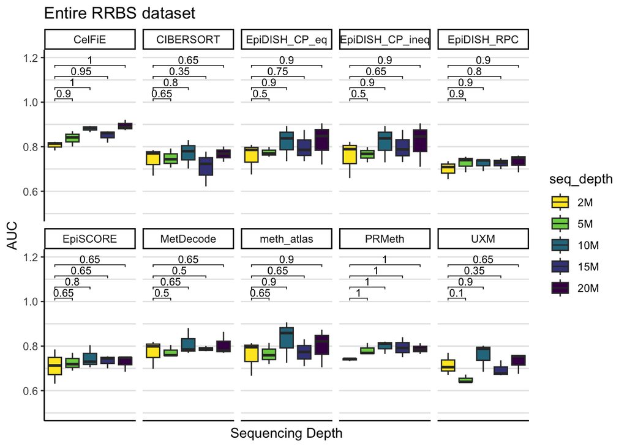

```r
# Order the seq depths levels
auc_rrbs$seq_depth <- factor(auc_rrbs$seq_depth, levels = c("2M", "5M", "10M", "15M", "20M"))

# Define comparisons
my_comparisons <- list(
  c("2M", "5M"),
  c("2M", "10M"),
  c("2M", "15M"),
  c("2M", "20M")
)

# Plot with adjusted p-values (FDR) and significance only if p.adj < 0.05
p1 <- ggplot(df, aes(x = seq_depth, y = AUC, fill = seq_depth)) +
    geom_boxplot(outlier.shape = NA) +
    facet_wrap(~ deconv_tool, ncol = 5) +
    stat_compare_means(
      method = "wilcox.test", comparisons = my_comparisons,
      p.adjust.method = "BH", label = "adj.p", hide.ns = F,
      method.args = list(alternative="greater"),
      label.y = c(1, 1.05, 1.10, 1.15), size = 3
    ) +
    labs(
      title = "Entire RRBS dataset",
      x = "Sequencing Depth",
      y = "AUC"
    ) +
    theme_classic() +
    theme(axis.text.x = element_blank(),
          axis.ticks.x = element_blank(),
          panel.grid.major.y = element_line(color = "grey90"),
          panel.grid.minor.y = element_line(color = "grey90")) +
    scale_fill_manual(values = c("2M"="#FDE725FF","5M"="#7AD151FF","10M"="#2A788EFF","15M"="#414487FF","20M"="#440154FF")) +
    ylim(0.5,1.2)
p1
```

```r
# Create a directory to save the plots (optional)
output_dir <- paste0(dir_path,"plots/03_seqdepth_robustness")
if (!dir.exists(output_dir)) dir.create(output_dir)

# Save the plot as an image
output_file <- file.path(output_dir, paste0("robustness_RRBS_aggregated.svg"))
ggsave(output_file, plot = p1, width = 8, height = 6)
```